# `forcats`: working with categorical data

Author

Casey Schine adapted from Emily Malcolm-White

The R package `forcats` is designed to make working with categorical variables easier and more efficient. It provides a set of functions that allow you to manipulate and analyze categorical data with ease. In this lesson, we’ll cover the basics of the `forcats` package and some of its most useful functions.

## Categorical Variables

Let’s review what categorical data is. Categorical data is a type of data that consists of categories or labels.

Examples of categorical data include:

- Colors (red, blue, green, etc.)
- Types of vehicles (sedan, SUV, truck)
- Educational degrees (high school, college, graduate school)

Categorical data can be further divided into two types: *nominal* and *ordinal*. Nominal data consists of categories that have no inherent order, while ordinal data consists of categories that have a natural order. For example, educational degrees are ordinal data because they can be ordered from least to most advanced.

## `mpg` Data

We will play with different functions in the `forcats` packages using the `mpg` dataset from earlier in the semester.

```r
library(forcats)
library(tidyverse)
data("mpg")
library(ggthemes)
```

Let’s take a look at a side-by-side boxplot:

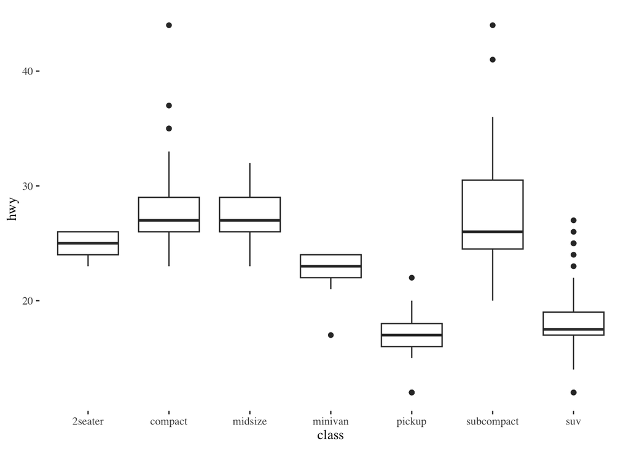

```r
# boxplot with x=class, y=hwy
mpg |>
  ggplot() +
  geom_boxplot(aes(x=class, y=hwy)) +
  theme_tufte()
```

## Reordering Factor Levels

One of the most useful functions is fct_relevel(), which allows you to reorder the levels of a factor. This can be useful when you want to change the default ordering of the levels or when you want to group certain levels together.

Is `class` a factor?

```r
# use is.factor() to inquire if class is a factor variable
# returns TRUE or FALSE

mpg$class |> is.factor()
```

```
[1] FALSE
```

```r
# with dplyr syntax (pipes)
# with pull()
mpg |>
  pull(class) |>
  is.factor()
```

```
[1] FALSE
```

Let’s make it a factor!

```r
# use mutate to write over class with new factor variable called class
# use as.factor()

mpg <- mpg |>
  mutate(class_fac = class |> as.factor())

mpg |>
  pull(class_fac) |>
  is.factor()
```

```
[1] TRUE
```

```r
mpg <- mpg |>
  mutate(class_fac=as.factor(class))

mpg |>
  pull(class_fac) |>
  is.factor()
```

```
[1] TRUE
```

Let’s check the levels and their current ordering!

```r
# use levels() to get factor levels
# levels() requires vector so must use pull() rather than select()

mpg |>
  pull(class_fac) |>
  levels()
```

```
[1] "2seater"    "compact"    "midsize"    "minivan"    "pickup"
[6] "subcompact" "suv"
```

To reorder the levels with `fct_relevel()`

```r
# use fct_relevel() for reordering factor
# fct_relevel( "compact","subcompact","midsize","2seater","minivan","suv","pickup")

mpg <- mpg |>
  mutate(class_fac = class_fac |> fct_relevel( "compact","subcompact","midsize","2seater","minivan","suv","pickup"))

mpg <- mpg |>
  mutate(class_fac = fct_relevel(class_fac, "compact","subcompact","midsize","2seater","minivan","suv","pickup"))

# look at the levels
mpg |>
  pull(class_fac) |>
  levels()
```

```
[1] "compact"    "subcompact" "midsize"    "2seater"    "minivan"
[6] "suv"        "pickup"
```

Let’s recreate our side-by-side boxplot now:

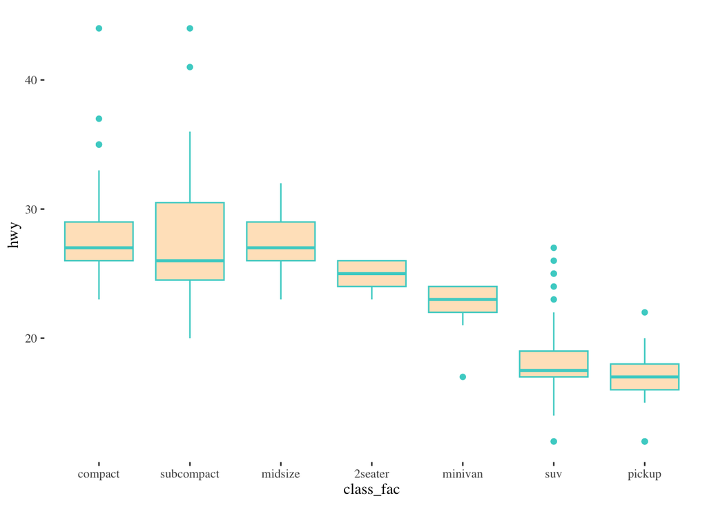

```r
# remake the boxplot to show the impact of the factor reordering

mpg |>
  ggplot() +
  geom_boxplot(aes(x=class_fac, y=hwy),
               fill="bisque", color="mediumturquoise") +
  theme_tufte()
```

Rather than reordering them manually by typing the order, you could also re-level by some numeric criteria using `fct_reorder()`. For example:

```r
#?fct_reorder

# use pipe within mutate as class |> fct_reorder(hwy, median)
mpg <- mpg |>
  mutate(class_fac = class_fac |> fct_reorder(.x= hwy, .fun=median))

mpg |>
  pull(class_fac) |>
  levels()
```

```
[1] "pickup"     "suv"        "minivan"    "2seater"    "subcompact"
[6] "compact"    "midsize"
```

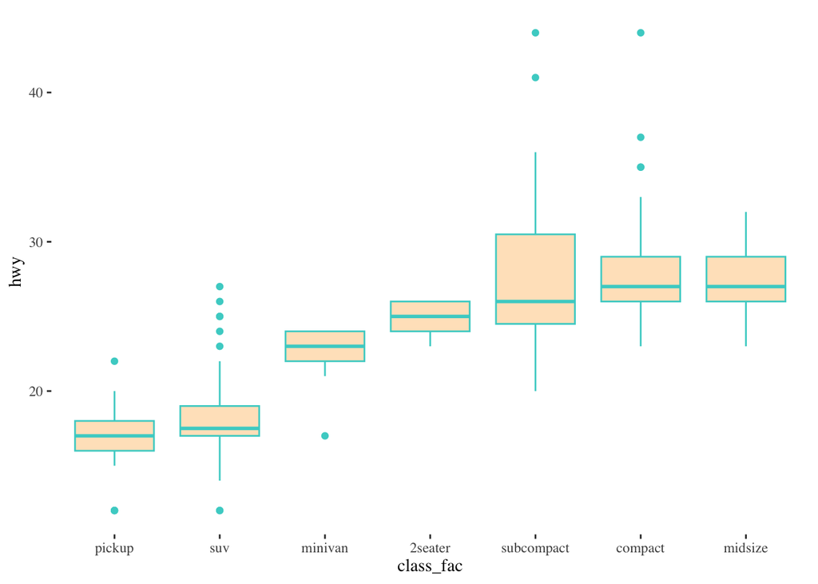

```r
mpg |>
  ggplot() +
  geom_boxplot(aes(x=class_fac, y=hwy),
               fill="bisque", color="mediumturquoise") +
  theme_tufte()
```

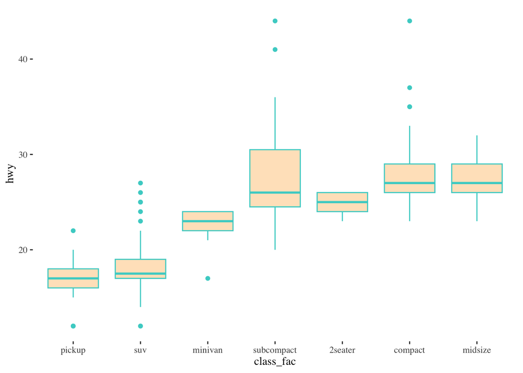

```r
# do the same thing without the pipe as fct_reorder(class, hwy, median)

mpg <- mpg |>
  mutate(class_fac = fct_reorder(.f= class_fac, .x= hwy, .fun=median))


# take a look at the order again using pull() |> levels()


# remake the boxplot again with the new order


# what other functions can we use to reorder???

mpg |>
  mutate(class_fac = fct_reorder(.f= class_fac, .x= hwy, .fun=min)) |>
  ggplot() +
  geom_boxplot(aes(x=class_fac, y=hwy),
               fill="bisque", color="mediumturquoise") +
  theme_tufte()
```

## Renaming Factor levels with `fct_recode`

Sometimes you might not like the way the levels are named.

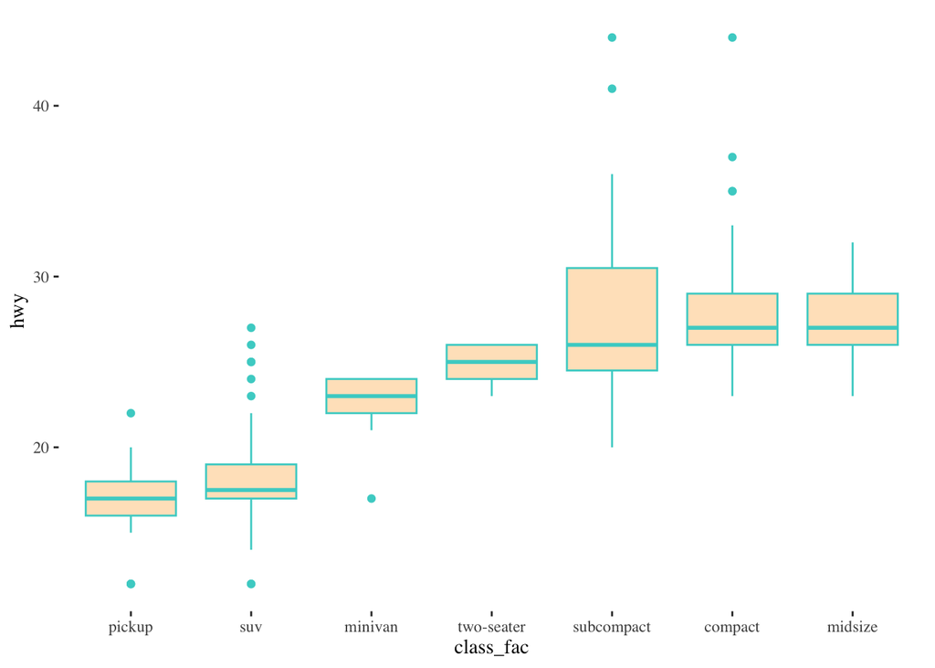

```r
# use fct_recode to change the name of a factor level in class
# fct_recode("two-seater" = "2seater")
## NEW NAME = OLD NAME

mpg <- mpg |>
  mutate(class_fac = fct_recode(class_fac, "two-seater" = "2seater"))


# take another look at the factor levels
mpg|>
ggplot() +
  geom_boxplot(aes(x=class_fac, y=hwy),
               fill="bisque", color="mediumturquoise") +
  theme_tufte()
```

## Factor Collapsing with `fct_collapse()`

Let’s say we wanted to create only two categories – cars and larger vehicles.

```r
# use fct_collapse to collapse class into cars and big factors
# mutate on new variable called class_two
# fct_collapse( cars = c("compact", "subcompact", "midsize", "two-seater"), big = c("pickup", "suv", "minivan"))

mpg <- mpg |>
  mutate(class_two = class_fac |> fct_collapse(cars = c("compact", "subcompact", "midsize", "two-seater"), big = c("pickup", "suv", "minivan")))

# take a look at the new variable factor levels
mpg |>
  pull(class_two) |>
  levels()
```

```
[1] "big"  "cars"
```

```r
mpg |>
  count(class_two)
```

```
# A tibble: 2 × 2
  class_two     n
  <fct>     <int>
1 big         106
2 cars        128
```

## Lumping into an other category

- `fct_lump_min()`: lumps levels that appear fewer than min times.
- `fct_lump_prop()`: lumps levels that appear in fewer than (or equal to) prop * n times.
- `fct_lump_n()` lumps all levels except for the n most frequent (or least frequent if n < 0)

```r
# count manufacturers in dataset

mpg |>
  count(manufacturer)
```

```
# A tibble: 15 × 2
   manufacturer     n
   <chr>        <int>
 1 audi            18
 2 chevrolet       19
 3 dodge           37
 4 ford            25
 5 honda            9
 6 hyundai         14
 7 jeep             8
 8 land rover       4
 9 lincoln          3
10 mercury          4
11 nissan          13
12 pontiac          5
13 subaru          14
14 toyota          34
15 volkswagen      27
```

```r
mpg |>
  pull(manufacturer) |>
  is.factor()
```

```
[1] FALSE
```

Let’s say we wanted only the manufacturers with at least 15 cars produced. Everything else we want to just be other:

```r
# make manufacturer lump variable using fct_lump_min(15)
mpg <- mpg |>
  mutate(man_fac = manufacturer |> as.factor()) |>
  mutate(man_fac = man_fac |> fct_lump_min(15))


# look at the result with count()

mpg |>
  count(man_fac)
```

```
# A tibble: 7 × 2
  man_fac        n
  <fct>      <int>
1 audi          18
2 chevrolet     19
3 dodge         37
4 ford          25
5 toyota        34
6 volkswagen    27
7 Other         74
```

```r
mpg |>
  count(manufacturer)
```

```
# A tibble: 15 × 2
   manufacturer     n
   <chr>        <int>
 1 audi            18
 2 chevrolet       19
 3 dodge           37
 4 ford            25
 5 honda            9
 6 hyundai         14
 7 jeep             8
 8 land rover       4
 9 lincoln          3
10 mercury          4
11 nissan          13
12 pontiac          5
13 subaru          14
14 toyota          34
15 volkswagen      27
```

```r
# now with fct_lump_n() for the top 5
mpg <- mpg |>
  mutate(man_fac = manufacturer |> as.factor()) |>
  mutate(man_fac = man_fac |> fct_lump_n(3))

# look at the result with count()
mpg |>
  count(man_fac)
```

```
# A tibble: 4 × 2
  man_fac        n
  <fct>      <int>
1 dodge         37
2 toyota        34
3 volkswagen    27
4 Other        136
```

```r
# now with fct_lump_prop() for 0.1 and -0.05

mpg |>
  mutate(man_fac = manufacturer |> as.factor()) |>
  mutate(man_fac = man_fac |> fct_lump_prop(0.05)) |>
  count(man_fac)
```

```
# A tibble: 10 × 2
   man_fac        n
   <fct>      <int>
 1 audi          18
 2 chevrolet     19
 3 dodge         37
 4 ford          25
 5 hyundai       14
 6 nissan        13
 7 subaru        14
 8 toyota        34
 9 volkswagen    27
10 Other         33
```

```r
# look at the result with count()

# reverse it to look at low manufacturer counts and collapse high numbers
mpg |>
  mutate(man_fac = manufacturer |> as.factor()) |>
  mutate(man_fac = man_fac |> fct_lump_prop(-0.05)) |>
  count(man_fac)
```

```
# A tibble: 7 × 2
  man_fac        n
  <fct>      <int>
1 honda          9
2 jeep           8
3 land rover     4
4 lincoln        3
5 mercury        4
6 pontiac        5
7 Other        201
```

## Kable Tables

Create a table using kableExtra:

```r
library(kableExtra)

# make table for manufacturer count before and after lumping
# using kbl() |> kable_styling()

# unlumped
mpg |>
count(manufacturer) |>
  kbl() |>
  kable_styling()
```

| manufacturer | n |
| --- | --- |
| audi | 18 |
| chevrolet | 19 |
| dodge | 37 |
| ford | 25 |
| honda | 9 |
| hyundai | 14 |
| jeep | 8 |
| land rover | 4 |
| lincoln | 3 |
| mercury | 4 |
| nissan | 13 |
| pontiac | 5 |
| subaru | 14 |
| toyota | 34 |
| volkswagen | 27 |

```r
# lumped
mpg |>
  mutate(man_fac = manufacturer |> as.factor()) |>
  mutate(man_fac = man_fac |> fct_lump_prop(0.1)) |>
  count(man_fac) |>
  kbl(col.names = c("Manufacturer", "Count")) |>
  kable_styling()
```

| Manufacturer | Count |
| --- | --- |
| dodge | 37 |
| ford | 25 |
| toyota | 34 |
| volkswagen | 27 |
| Other | 111 |

```r
## Tables + factors: controlling order and labels

# make a new table using count(class) variable
# then |> kbl() |> kable_styling()

mpg |>
  count(class) |>
  kbl() |>
  kable_styling()
```

| class | n |
| --- | --- |
| 2seater | 5 |
| compact | 47 |
| midsize | 41 |
| minivan | 11 |
| pickup | 33 |
| subcompact | 35 |
| suv | 62 |

```r
mpg |>
  count(class_fac) |>
  kbl() |>
  kable_styling()
```

| class_fac | n |
| --- | --- |
| pickup | 33 |
| suv | 62 |
| minivan | 11 |
| two-seater | 5 |
| subcompact | 35 |
| compact | 47 |
| midsize | 41 |

```r
# you can reorder the factor before feeding it into the table to control the order
# let's go back to our first reordering
# fct_relevel( "compact","subcompact","midsize","2seater","minivan","suv","pickup"))
mpg |>
  mutate(class_fac = class_fac |> fct_relevel( "compact","subcompact","midsize","two-seater","minivan","suv","pickup")) |>
  count(class_fac) |>
  kbl() |>
  kable_styling()
```

| class_fac | n |
| --- | --- |
| compact | 47 |
| subcompact | 35 |
| midsize | 41 |
| two-seater | 5 |
| minivan | 11 |
| suv | 62 |
| pickup | 33 |

```r
# then add a caption in the kbl() function as caption="caption goes here"



# what if we want to show something other than count()
# we can use group_by() and summarize() to get statistics for each group

mpg |>
  mutate(class_fac = class_fac |> fct_reorder(.x= hwy, .fun=median)) |>
  group_by(class_fac) |>
  summarize(count=n(),
            median_hwy= median(hwy)) |>
  kbl() |>
  kable_styling()
```

| class_fac | count | median_hwy |
| --- | --- | --- |
| pickup | 33 | 17.0 |
| suv | 62 | 17.5 |
| minivan | 11 | 23.0 |
| two-seater | 5 | 25.0 |
| subcompact | 35 | 26.0 |
| compact | 47 | 27.0 |
| midsize | 41 | 27.0 |

```r
# we can also use the fct_reorder() function to reorder the factor by a calculated value (as we did above)
# class = fct_reorder(class, hwy, .fun = median)
```

We can also control aspects of the table and how it looks using arguments in the `kbl()` and `kable_styling()` functions.

```r
# how can we control aspects of the table
#?kbl to look at some of the options

# can set the number of digits using the digits=x argument in kbl()

# also col.names argument to change the column names for the output table

mpg |>
  mutate(class_fac = class_fac |> fct_reorder(.x= hwy, .fun=median)) |>
  group_by(class_fac) |>
  summarize(count=n(),
            median_hwy= median(hwy)) |>
  kbl(digits=0,
      col.names=c("Vehicle Class", "Count", "Median Hwy MPG"),
      caption="Awesome Table") |>
  kable_styling()
```

Awesome Table

| Vehicle Class | Count | Median Hwy MPG |
| --- | --- | --- |
| pickup | 33 | 17 |
| suv | 62 | 18 |
| minivan | 11 | 23 |
| two-seater | 5 | 25 |
| subcompact | 35 | 26 |
| compact | 47 | 27 |
| midsize | 41 | 27 |